# Module 3, Lecture-Lab 1: Digital Content Collection

SKOD52: Sustainability Communication 2026

nils.holmberg@iko.lu.se

## Module 3, Lecture-Lab 1

- One organization, its published web content
- **Part 1:** ethics and web scraping (Colab)
- **Part 2:** theory → research questions
- Group work in breakout rooms

|  | Time | Activity |
| --- | --- | --- |
| 0 | 1st hour | Ethics, scraping, Colab demo |
| 1 | Breakout | Scrape your own organization |
| 2 | 2nd hour | Theory, content analysis, codebook |
| 3 | Breakout | Draft research questions |
| 4 | End | Intro to Lecture-Lab 3 |

## Collecting Content Data

- **PDF capture:** manual, keeps layout
- **Scraping:** code downloads and extracts text
- **API:** structured data, platform’s terms
- Method shapes your corpus

```python
pd.DataFrame({
    "method": ["PDF capture", "scraping", "API"],
    "scale":  ["low", "high", "high"],
    "effort": ["manual", "code", "code + key"],
    "noise":  ["layout", "menus", "low"],
})
```

|  | method | scale | effort | noise |
| --- | --- | --- | --- | --- |
| 0 | PDF capture | low | manual | layout |
| 1 | scraping | high | code | menus |
| 2 | API | high | code + key | low |

## Ethics of Web Scraping

- Public ≠ free: check **terms of service**
- Analyze, don’t republish texts
- **GDPR:** avoid personal data
- Pause between requests, honest **User-Agent**

```python
pd.DataFrame({
    "risk": ["terms of service", "copyright", "personal data",
             "server load", "anonymity"],
    "mitigation": ["read them first", "keep texts private",
                   "skip / anonymize", "DELAY between requests",
                   "honest User-Agent"],
})
```

|  | risk | mitigation |
| --- | --- | --- |
| 0 | terms of service | read them first |
| 1 | copyright | keep texts private |
| 2 | personal data | skip / anonymize |
| 3 | server load | DELAY between requests |
| 4 | anonymity | honest User-Agent |

## Site Maps and robots.txt

- `robots.txt`: what robots may visit
- `Disallow:` paths are off limits
- **Site map:** list of all public pages
- Linked from `robots.txt` via `Sitemap:`

```python
robots_txt = """User-agent: *
Disallow: /search
Allow: /
Sitemap: https://www.equinor.com/sitemap.xml"""

rp = RobotFileParser()
rp.parse(robots_txt.splitlines())
print(rp.site_maps())

paths = ["/sustainability/human-rights", "/search?q=wind"]
pd.DataFrame({"path": paths,
              "can_fetch": [rp.can_fetch("*", "https://www.equinor.com" + p)
                            for p in paths]})
```

```
['https://www.equinor.com/sitemap.xml']
```

|  | path | can_fetch |
| --- | --- | --- |
| 0 | /sustainability/human-rights | True |
| 1 | /search?q=wind | False |

## Polite Requests

- `requests.get(url)` downloads HTML
- **User-Agent** header says who asks
- `time.sleep(DELAY)` between pages
- Status **200** = OK, keep the raw HTML

```python
HEADERS = {"User-Agent": "SKOD52 student project, Lund University"}
DELAY = 2   # seconds

req = requests.Request(
    "GET", "https://www.equinor.com/sustainability/human-rights",
    headers=HEADERS).prepare()

pd.DataFrame(req.headers.items(), columns=["header", "value"])
```

|  | header | value |
| --- | --- | --- |
| 0 | User-Agent | SKOD52 student project, Lund University |

## Scraping Tools on Colab

- **Static:** `requests` + `BeautifulSoup`
- **Dynamic (JavaScript):** headless browser
- Equinor is static → preinstalled tools suffice

```python
pd.DataFrame({
    "tool": ["requests", "BeautifulSoup", "lxml",
             "trafilatura", "Playwright", "Selenium"],
    "on Colab": ["yes", "yes", "yes", "pip", "pip + browser", "pip + browser"],
    "pages": ["static", "static", "static", "static", "dynamic", "dynamic"],
})
```

|  | tool | on Colab | pages |
| --- | --- | --- | --- |
| 0 | requests | yes | static |
| 1 | BeautifulSoup | yes | static |
| 2 | lxml | yes | static |
| 3 | trafilatura | pip | static |
| 4 | Playwright | pip + browser | dynamic |
| 5 | Selenium | pip + browser | dynamic |

## A List of URLs

- Filter the site map to your section
- **Content changes fast:** pages renamed, rewritten
- Record **scrape date**, cite your snapshot or web.archive.org

```python
sitemap_xml = """<urlset>
<url><loc>https://www.equinor.com/about-us</loc></url>
<url><loc>https://www.equinor.com/sustainability/human-rights</loc></url>
<url><loc>https://www.equinor.com/sustainability/just-transition</loc></url>
<url><loc>https://www.equinor.com/sustainability/reporting</loc></url>
</urlset>"""

locs = [loc.text for loc in BeautifulSoup(sitemap_xml, "xml").find_all("loc")]
df_urls = pd.DataFrame({"url": [u for u in locs if "/sustainability/" in u]})
df_urls.insert(0, "slug", df_urls["url"].str.split("/").str[-1])
df_urls
```

|  | slug | url |
| --- | --- | --- |
| 0 | human-rights | https://www.equinor.com/sustainability/human... |
| 1 | just-transition | https://www.equinor.com/sustainability/just-... |
| 2 | reporting | https://www.equinor.com/sustainability/repor... |

## HTML Anatomy

- HTML is a **tree of tags**
- Text sits in `<h1>`, `<p>`, `<li>`
- `<nav>`, footer, scripts = **boilerplate**
- Inspect first: right-click → *Inspect*

```python
html = """<html><head><title></title><meta property="og:title" content="Human rights"></head><body><nav>Home › Sustainability</nav><article><h1>Human rights</h1><p>We respect internationally recognized human rights.</p><ul><li>Due diligence</li><li>Grievance mechanisms</li></ul></article><footer>Privacy · Cookies</footer></body></html>"""

soup = BeautifulSoup(html, "html.parser")
rows = []
for tag in soup.body.find_all(True):
    if tag.name == "ul":                 # stop here to keep the table short
        break
    depth = len(list(tag.parents)) - 3   # 0 = child of <body>
    own = " ".join(tag.find_all(string=True, recursive=False)).strip()
    rows.append(("└─ " * depth + tag.name, own))   # leading spaces get trimmed
pd.DataFrame(rows, columns=["tag", "own text"])
```

|  | tag | own text |
| --- | --- | --- |
| 0 | nav | Home › Sustainability |
| 1 | article |  |
| 2 | └─ h1 | Human rights |
| 3 | └─ p | We respect internationally recognized human ... |

## BeautifulSoup

- `find()` first match, `find_all()` all
- `.get_text()` returns the text only
- Equinor’s `<title>` is **empty** → use `og:title`

```python
print("title:   ", repr(soup.title.get_text()))
print("og:title:", soup.find("meta", property="og:title")["content"])

pd.DataFrame(
    [(t.name, t.get_text(strip=True))
     for t in soup.find_all(["h1", "p", "li"])],
    columns=["tag", "text"]
)
```

```
title:    ''
og:title: Human rights
```

|  | tag | text |
| --- | --- | --- |
| 0 | h1 | Human rights |
| 1 | p | We respect internationally recognized human ... |
| 2 | li | Due diligence |
| 3 | li | Grievance mechanisms |

## Text Extraction

- `get_text()` includes boilerplate
- Target `<article>` or `<main>` instead
- Every site differs: inspect, then adapt

```python
whole = soup.get_text(" ", strip=True)
main  = soup.find("article").get_text(" ", strip=True)

pd.DataFrame({
    "method": ["soup.get_text()", "article only"],
    "words":  [len(whole.split()), len(main.split())],
    "starts": [whole[:30], main[:30]],
})
```

|  | method | words | starts |
| --- | --- | --- | --- |
| 0 | soup.get_text() | 18 | Home › Sustainability Human ri |
| 1 | article only | 12 | Human rights We respect intern |

## From HTML to a DataFrame

- One row per page → `df_web.tsv`
- **Colab:** `lecture_lab_1.ipynb`
- Breakout: scrape your own organization

```python
from datetime import date

rows = []
for text_id, page in [("equinor03", html)]:
    s = BeautifulSoup(page, "html.parser")
    text = s.find("article").get_text(" ", strip=True)
    rows.append({"text_id": text_id,
                 "title": s.find("meta", property="og:title")["content"],
                 "scraped_at": date.today().isoformat(),
                 "text_wordcount": len(text.split())})
pd.DataFrame(rows)
```

|  | text_id | title | scraped_at | text_wordcount |
| --- | --- | --- | --- | --- |
| 0 | equinor03 | Human rights | 2026-11-26 | 12 |

## Break!

**Lecture-Lab 1**

- Lecture notes: [available on github!](https://cca-cce.github.io/osm-comm/web/edu/skod52-cca01.html)
- Lab notebook: [available on colab!](https://colab.research.google.com/github/cca-cce/osm-comm/blob/main/jnb/skod52/lecture_lab_1.ipynb)

## Theory: From Matt’s Lecture

Key theories from Freear (2026):

|  | Theory | Key concept | What it looks like in text |
| --- | --- | --- | --- |
| 0 | Shareholder primacy | profit as the only responsibility | returns, value, shareholders, growth |
| 1 | Stakeholder theory | groups who affect / are affected | employees, communities, suppliers, NGOs |
| 2 | Salience | power, legitimacy, urgency | who is named, how often, in which role |
| 3 | Legitimacy | pragmatic, moral, cognitive | benefits, values, "responsible", "trusted" |
| 4 | Aspirational talk | talk ahead of action | ambition, aim, will, commit, by 2030 |
| 5 | Enshittification | value shifts to shareholders | pricing, lock-in, users vs. investors |
| 6 | Political CSR | firms as political actors | lobbying, MSIs, human rights, standards |
| 7 | Corporate governance | who directs and controls | board, committee, oversight, remuneration |

Sources: Friedman (1970); Freeman (1984); Mitchell et al. (1997); Suchman (1995); Christensen et al. (2013); Doctorow (2025); Scherer and Palazzo (2007); Rasche et al. (2023)

## Stakeholders and Salience

- Groups who affect or are affected by the firm (Freeman 1984)
- **Salience:** power, legitimacy, urgency (Mitchell et al. 1997)
- **In text:** which groups are named, as actors or objects?

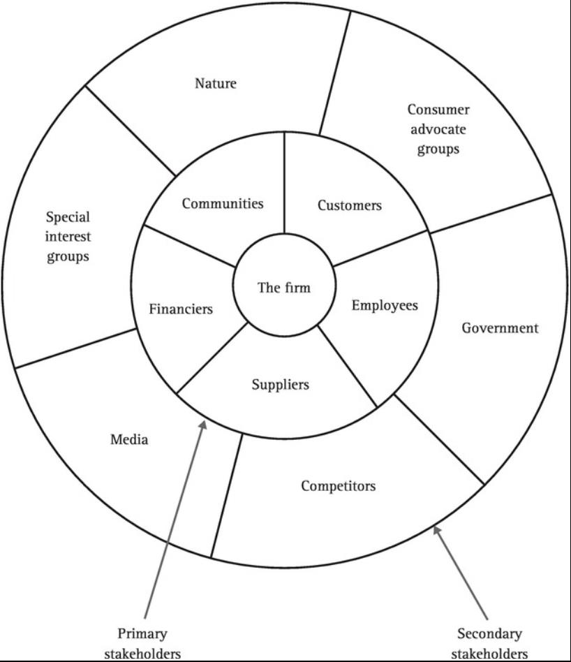

Image: Freeman (1984), in Freear (2026)

## Legitimacy and Aspirational Talk

- Pragmatic, moral, cognitive **legitimacy** (Suchman 1995)
- **Aspirational talk:** talk ahead of action (Christensen et al. 2013)
- **In text:** *ambition, aim, will* vs. results

[figure not shown]

Image: Freear (2026)

## Political CSR and Enshittification

- Firms fill **governance gaps** (Scherer and Palazzo 2007)
- **Enshittification:** value shifts to shareholders (Doctorow 2025)
- **In text:** standards, multi-stakeholder initiative (MSIs), regulation, who benefits

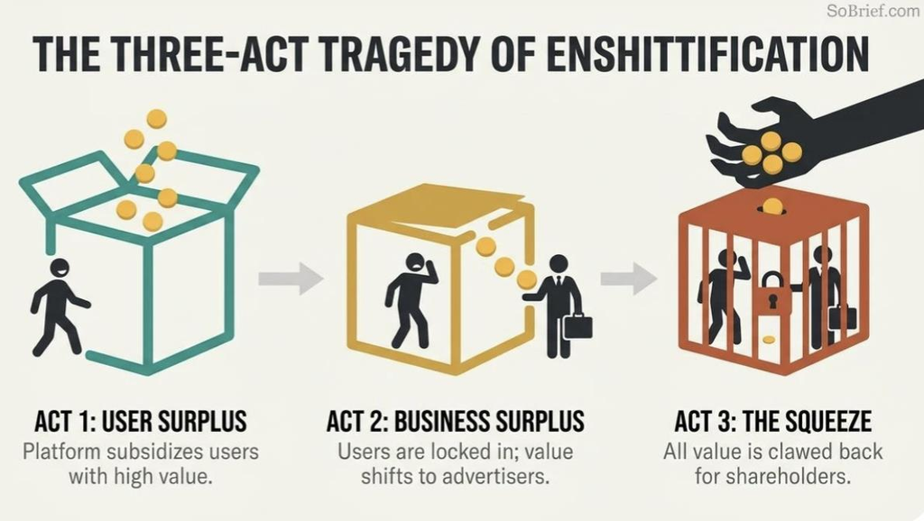

Image: Freear (2026)

## Corporate Governance

- How firms are directed and controlled (Cadbury 1992)
- Shareholder value: ideology, not law (Stout 2012)
- **In text:** board, oversight, ESG-linked pay

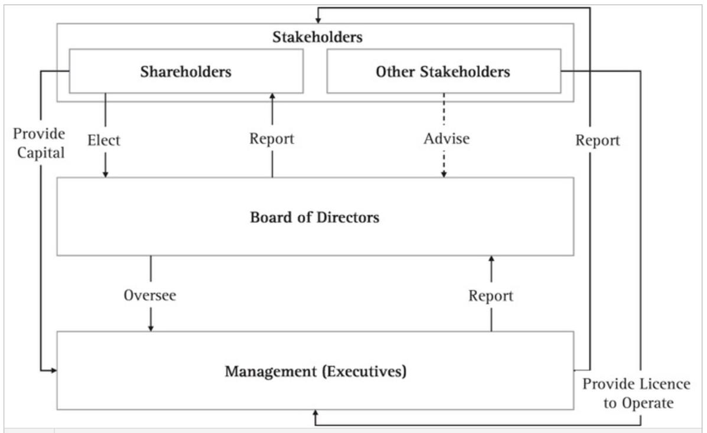

Image: Rasche et al. (2023), in Freear (2026)

## Quantitative Content Analysis

- Systematic, quantitative analysis of messages (Neuendorf 2017)
- Variables defined from **theory** before coding
- **Reliability:** do coders agree?

|  | Step | In our project |
| --- | --- | --- |
| 0 | Theory & rationale | one theory from Matt's lecture |
| 1 | Conceptualization | e.g. aspirational talk |
| 2 | Operationalization | future / modal markers |
| 3 | Unit & sample | sentences on 10 web pages |
| 4 | Codebook | variables + categories |
| 5 | Reliability | human vs. GenAI coding |
| 6 | Tabulation | pandas tables, plots |

## Designing a Codebook

- One **variable** per concept
- Exhaustive, exclusive **categories**
- **Scales:** nominal, ordinal, interval

|  | Variable | Categories | Scale |
| --- | --- | --- | --- |
| 0 | stakeholder | employees, communities, investors, … | nominal |
| 1 | time frame | past, present, future | nominal |
| 2 | legitimacy | pragmatic, moral, cognitive | nominal |
| 3 | commitment | 1 vague … 5 specific target | ordinal |
| 4 | tone | 1 negative … 5 positive | interval |

## Codebook with GenAI

- GenAI **drafts** the codebook from theory
- GenAI **codes**: sentence → category
- Compare with hand coding, revise

```
You are coding sustainability web texts.
Variable: time frame
Categories:
  past    = reports something already done
  present = describes ongoing practice
  future  = ambition, aim, plan, target
Sentence: "We aim to reach net zero by 2050."
Answer with one category only.
```

|  | Sentence | Human | GenAI |
| --- | --- | --- | --- |
| 0 | s1 | future | future |
| 1 | s2 | past | present |
| 2 | s3 | present | present |

## Deductive or Abductive?

- **Deductive:** theory first, then code
- **Abductive:** results first, theory explains
- Abductive recommended: fits the NLP labs

|  | aspect | Deductive | Abductive |
| --- | --- | --- | --- |
| 0 | starts from | theory | results |
| 1 | theory used | before | after |
| 2 | method | quant CA, codebook | CCA, NLP outputs |
| 3 | question | "Is X more frequent than Y?" | "Why does X stand out?" |
| 4 | risk | rigid categories | post-hoc stories |

## Sensemaking Research Questions

|  | Theory | Example research question | Mode | Method |
| --- | --- | --- | --- | --- |
| 0 | Stakeholder / salience | Which stakeholder groups appear most often, and as actors or objects? | abductive | Lab 2 frequencies, NER |
| 1 | Aspirational talk | How do future-oriented statements cluster across pages, and around which topics? | abductive | Lab 3 KWIC (will, aim, ambition) |
| 2 | Legitimacy | Do pages on contested issues (human rights, transition) sound more positive than others? | deductive | Lab 3 sentiment |
| 3 | Political CSR | Which standards, MSIs and regulators does the organization refer to, and in what context? | abductive | Lab 2 NER + Lab 3 KWIC |
| 4 | Shareholder vs stakeholder | Which words distinguish investor-oriented pages from community-oriented pages? | abductive | Lab 3 TF-IDF |
| 5 | Governance | Is sustainability framed as a board responsibility or as communication? | deductive | codebook + GenAI coding |

## Next steps

**Breakout rooms**

- Discuss theories, write 1–2 RQs
- Bring a draft RQ and its theory
- Applications of NLP, next week

**References**

Cadbury, Adrian. 1992. *Report of the Committee on the Financial Aspects of Corporate Governance*. Gee.

Christensen, Lars Thøger, Mette Morsing, and Ole Thyssen. 2013. “CSR as Aspirational Talk.” *Organization* 20 (3): 372–93. https://doi.org/10.1177/1350508413478310.

Doctorow, Cory. 2025. *Enshittification: Why Everything Suddenly Got Worse and What to Do about It*. MCD / Farrar, Straus; Giroux.

Freear, Matt. 2026. *Shareholders, Stakeholders & the Enshittocene*. Lecture slides, SKOD52, Department of Communication, Lund University.

Freeman, R. Edward. 1984. *Strategic Management: A Stakeholder Approach*. Pitman.

Friedman, Milton. 1970. “The Social Responsibility of Business Is to Increase Its Profits.” *The New York Times Magazine*.

Mitchell, Ronald K., Bradley R. Agle, and Donna J. Wood. 1997. “Toward a Theory of Stakeholder Identification and Salience: Defining the Principle of Who and What Really Counts.” *Academy of Management Review* 22 (4): 853–86. https://doi.org/10.5465/amr.1997.9711022105.

Neuendorf, Kimberly A. 2017. *The Content Analysis Guidebook*. Sage.

Rasche, Andreas, Mette Morsing, Jeremy Moon, and Arno Kourula, eds. 2023. *Corporate Sustainability: Managing Responsible Business in a Globalised World*. 2nd ed. Cambridge University Press.

Scherer, Andreas Georg, and Guido Palazzo. 2007. “Toward a Political Conception of Corporate Responsibility: Business and Society Seen from a Habermasian Perspective.” *Academy of Management Review* 32 (4): 1096–120. https://doi.org/10.5465/amr.2007.26585837.

Stout, Lynn. 2012. *The Shareholder Value Myth: How Putting Shareholders First Harms Investors, Corporations, and the Public*. Berrett-Koehler.

Suchman, Mark C. 1995. “Managing Legitimacy: Strategic and Institutional Approaches.” *Academy of Management Review* 20 (3): 571–610. https://doi.org/10.5465/amr.1995.9508080331.